# Practice 04: Probability Distributions and Simulation in R

Marcos Cunchillos Just

2026-11-17

## Overview

This practice applies the `d`/`p`/`q`/`r` family of R functions to the main discrete and continuous probability distributions (binomial, Poisson, normal), combinatorics with `gtools`, random sampling, and a distribution-fitting case study on the Old Faithful geyser dataset.

| Prefix | Meaning | Example |
| --- | --- | --- |
| `d` | Density / probability mass: $P(X = x)$ | `dbinom(3, 10, 0.5)` |
| `p` | Cumulative probability: $P(X \le x)$ | `pbinom(3, 10, 0.5)` |
| `q` | Quantile (inverse of `p`) | `qnorm(0.975)` |
| `r` | Random number generation | `rnorm(100)` |

```r
library(gtools)
```

## Exercise 1: Binomial distribution (clinical trial)

In a clinical trial, a sample of 100 patients is taken. The probability that a patient suffers from a cardiovascular disease is 0.45. Compute:

```r
n_patients <- 100
p_disease  <- 0.45
```

**a)** The probability that exactly 30 patients have the disease: $P(X = 30)$.

```r
dbinom(30, size = n_patients, prob = p_disease)
```

```
## [1] 0.0007757151
```

**b)** The probability that **at least** 15 patients have the disease: $P(X \ge 15)$. Is this result surprising?

For a discrete variable, $P(X \ge 15) = 1 - P(X \le 14)$, so the upper limit passed to `pbinom()` must be **14**, not 15.

```r
pbinom(14, size = n_patients, prob = p_disease, lower.tail = FALSE)
```

```
## [1] 1
```

The probability is practically 1. This is expected: with 100 patients and $p = 0.45$ the expected number of cases is $np = 45$, so having fewer than 15 cases would be an extremely unlikely event.

**c)** The probability that **between 5 and 10 patients (both inclusive)** have the disease: $P(5 \le X \le 10)$.

For discrete variables: $P(a \le X \le b) = F(b) - F(a - 1)$.

```r
pbinom(10, n_patients, p_disease) - pbinom(4, n_patients, p_disease)
```

```
## [1] 2.914798e-14
```

## Exercise 2: Binomial simulation and Poisson distribution

**a)** Generate 500 observations from a binomial distribution $B(1, 0.5)$ and store them in a vector called `bino`. Compute the absolute and relative frequencies. What do you observe?

```r
set.seed(123)
bino <- rbinom(n = 500, size = 1, prob = 0.5)

abs_freq <- table(bino)
rel_freq <- prop.table(abs_freq)

abs_freq
```

```
## bino
##   0   1
## 265 235
```

```r
rel_freq
```

```
## bino
##    0    1
## 0.53 0.47
```

Both outcomes appear with a frequency close to 0.5, as expected for a fair Bernoulli trial. The small deviation from exactly 250/250 is sampling variability, and it shrinks as the sample size grows (law of large numbers).

**b)** On average, 12 individuals per minute cross a street. Compute the probability that **18 or more** individuals cross in any given minute: $P(X \ge 18)$.

```r
ppois(17, lambda = 12, lower.tail = FALSE)
```

```
## [1] 0.0629663
```

## Exercise 3: Poisson distribution (drug factory)

A factory produces headache drugs at a rate that follows a Poisson distribution with $\lambda = 0.5$ drugs per minute. Compute:

**a)** The probability that exactly one drug is produced in a random minute.

```r
lambda_min <- 0.5
dpois(1, lambda = lambda_min)
```

```
## [1] 0.3032653
```

**b)** The probability that **at most** 3 drugs are produced in a random minute.

```r
ppois(3, lambda = lambda_min)
```

```
## [1] 0.9982484
```

**c)** The probability that 4 drugs are produced in 8 minutes.

The Poisson parameter scales with the length of the interval: $\lambda_{8\,min} = 0.5 \times 8 = 4$.

```r
lambda_8min <- lambda_min * 8
dpois(4, lambda = lambda_8min)
```

```
## [1] 0.1953668
```

## Exercise 4: Sampling from an urn

An urn contains 40 balls: 25 yellow and 15 green. Yellow balls are coded as 1 and green balls as 0.

**a)** Probability of drawing each type of ball.

```r
n_total  <- 40
n_yellow <- 25
n_green  <- n_total - n_yellow

prob_yellow <- n_yellow / n_total
prob_green  <- n_green / n_total

c(green = prob_green, yellow = prob_yellow)
```

```
##  green yellow
##  0.375  0.625
```

**b)** Simulate the draw of one ball.

```r
set.seed(123)
sample(c(0, 1), size = 1, prob = c(prob_green, prob_yellow))
```

```
## [1] 1
```

**c)** Simulate 9 draws **with replacement**.

```r
sample(c(0, 1), size = 9, replace = TRUE, prob = c(prob_green, prob_yellow))
```

```
## [1] 0 1 0 0 1 1 0 1 1
```

## Exercise 5: Binomial and normal distributions

**a)** Probability of obtaining exactly four heads in six tosses of a fair coin.

```r
dbinom(4, size = 6, prob = 0.5)
```

```
## [1] 0.234375
```

**b)** Probability of obtaining **at most** four heads in six tosses.

```r
pbinom(4, size = 6, prob = 0.5)
```

```
## [1] 0.890625
```

**c)** Generate 10 pseudo-random values from $X \sim B(6, 0.5)$.

```r
set.seed(123)
rbinom(10, size = 6, prob = 0.5)
```

```
##  [1] 2 4 3 4 5 1 3 5 3 3
```

**d)** Generate a sample of size 10,000 from a normal distribution $N(3, 2)$ and plot a histogram with coloured bars.

Following R’s convention, the second parameter is the standard deviation.

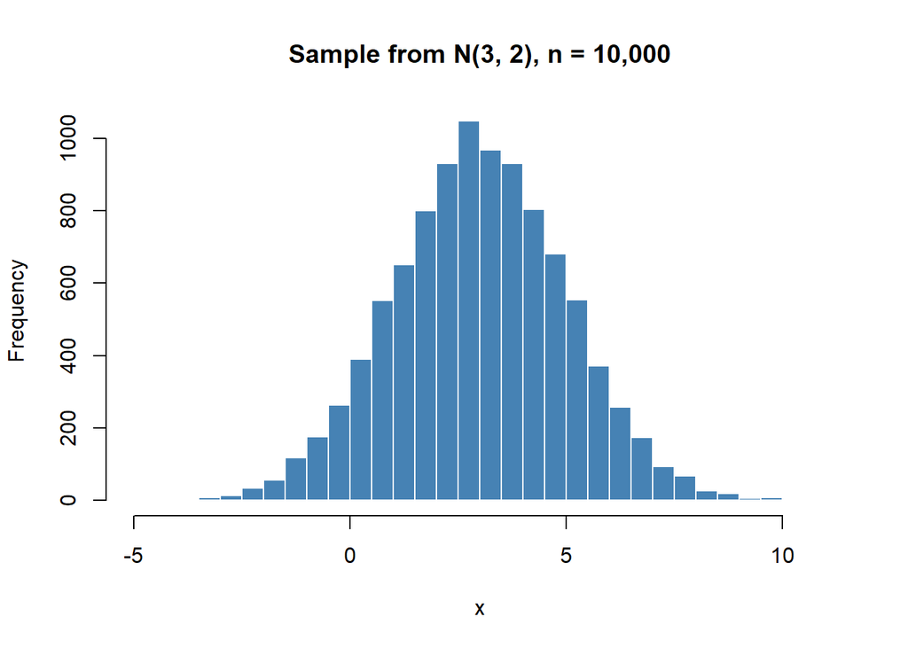

```r
set.seed(123)
normal_sample <- rnorm(10000, mean = 3, sd = 2)

hist(normal_sample,
     breaks = 40,
     col    = "steelblue",
     border = "white",
     main   = "Sample from N(3, 2), n = 10,000",
     xlab   = "x")
```

**e)** Check whether the sum of two independent normal variables $X_1 \sim N(6, 0.5)$ and $X_2 \sim N(3, 0.6)$ is also normal.

Theory: the sum of independent normal variables is normal, with $\mu = \mu_1 + \mu_2 = 9$ and $\sigma^2 = \sigma_1^2 + \sigma_2^2$, that is $\sigma = \sqrt{0.5^2 + 0.6^2} \approx 0.781$.

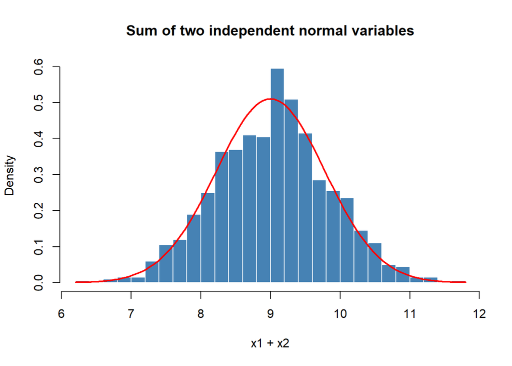

```r
set.seed(123)
x1 <- rnorm(1000, mean = 6, sd = 0.5)
x2 <- rnorm(1000, mean = 3, sd = 0.6)
x_sum <- x1 + x2

hist(x_sum,
     breaks = 30,
     prob   = TRUE,
     col    = "steelblue",
     border = "white",
     main   = "Sum of two independent normal variables",
     xlab   = "x1 + x2")

# Overlay the theoretical normal density
curve(dnorm(x, mean = 9, sd = sqrt(0.5^2 + 0.6^2)),
      add = TRUE, col = "red", lwd = 2)
```

```r
# Empirical vs theoretical parameters, and a formal normality test
c(empirical_mean = mean(x_sum), theoretical_mean = 9)
```

```
##   empirical_mean theoretical_mean
##         9.033543         9.000000
```

```r
c(empirical_sd = sd(x_sum), theoretical_sd = sqrt(0.5^2 + 0.6^2))
```

```
##   empirical_sd theoretical_sd
##       0.815364       0.781025
```

```r
shapiro.test(x_sum)
```

```
##
##  Shapiro-Wilk normality test
##
## data:  x_sum
## W = 0.99913, p-value = 0.9298
```

The histogram follows the theoretical density, and the Shapiro-Wilk test does not reject normality ($H_0$: the data are normal), which confirms the result.

## Exercise 6: Dice game simulation

A game consists of rolling a die 5 times per round. We simulate 8 rounds and identify the **winning rounds**: those with at least one 6.

```r
set.seed(123)

# Each column is one round (5 rolls)
rounds <- replicate(8, sample(1:6, size = 5, replace = TRUE))
colnames(rounds) <- paste("Round", 1:8)
rounds
```

```
##      Round 1 Round 2 Round 3 Round 4 Round 5 Round 6 Round 7 Round 8
## [1,]       3       6       6       3       1       1       1       5
## [2,]       6       3       1       3       5       6       3       1
## [3,]       3       5       2       1       3       3       5       1
## [4,]       2       4       3       4       2       4       4       2
## [5,]       2       6       5       1       2       6       2       3
```

```r
# A round is winning if any of its rolls is a 6
winning_rounds <- apply(rounds == 6, MARGIN = 2, FUN = any)
winning_rounds
```

```
## Round 1 Round 2 Round 3 Round 4 Round 5 Round 6 Round 7 Round 8
##    TRUE    TRUE    TRUE   FALSE   FALSE    TRUE   FALSE   FALSE
```

```r
sum(winning_rounds)
```

```
## [1] 4
```

Theoretical check: the probability of at least one 6 in 5 rolls is $1 - (5/6)^5 \approx 0.598$, so about 5 winning rounds out of 8 are expected.

```r
1 - (5 / 6)^5
```

```
## [1] 0.5981224
```

## Exercise 7: Combinatorics with `gtools`

A bowl contains three types of apples (golden, fuji, gala).

**a)** How many permutations of 2 apples are there (with repetition)?

Theory: $3^2 = 9$ ordered pairs (the statement writes “32”, which is a typo for the power $3^2$).

```r
apples <- c("golden", "fuji", "gala")

permutations(n = 3, r = 2, v = apples, repeats.allowed = TRUE)
```

```
##       [,1]     [,2]
##  [1,] "fuji"   "fuji"
##  [2,] "fuji"   "gala"
##  [3,] "fuji"   "golden"
##  [4,] "gala"   "fuji"
##  [5,] "gala"   "gala"
##  [6,] "gala"   "golden"
##  [7,] "golden" "fuji"
##  [8,] "golden" "gala"
##  [9,] "golden" "golden"
```

```r
nrow(permutations(3, 2, apples, repeats.allowed = TRUE))
```

```
## [1] 9
```

**b)** How many combinations (with repetition, order does not matter)?

```r
combinations(n = 3, r = 2, v = apples, repeats.allowed = TRUE)
```

```
##      [,1]     [,2]
## [1,] "fuji"   "fuji"
## [2,] "fuji"   "gala"
## [3,] "fuji"   "golden"
## [4,] "gala"   "gala"
## [5,] "gala"   "golden"
## [6,] "golden" "golden"
```

```r
nrow(combinations(3, 2, apples, repeats.allowed = TRUE))
```

```
## [1] 6
```

**c)** How many codons (triplets) have **all their nucleotides different**? The nucleotides are A, T, G and C.

Each nucleotide can be used only once, so repetition must **not** be allowed: $4 \times 3 \times 2 = 24$. (With `repeats.allowed = TRUE` the result would be $4^3 = 64$, which counts *all* possible codons, not only those with distinct nucleotides.)

```r
nucleotides <- c("A", "T", "G", "C")

distinct_codons <- permutations(n = 4, r = 3, v = nucleotides,
                                repeats.allowed = FALSE)
nrow(distinct_codons)
```

```
## [1] 24
```

## Exercise 8: Normal distribution $N(20, 9)$

Given $X \sim N(\mu, \sigma^2) = N(20, 9)$. The statement uses the $N(\mu, \sigma^2)$ notation, so the **variance is 9** and the standard deviation is $\sigma = 3$. R’s functions use the standard deviation.

```r
mu    <- 20
sigma <- sqrt(9)
```

**a)** Quartiles (0.25, 0.5, 0.75).

```r
qnorm(c(0.25, 0.5, 0.75), mean = mu, sd = sigma)
```

```
## [1] 17.97653 20.00000 22.02347
```

**b)** $P(X \ge 8)$. For a continuous variable, $P(X \ge 8) = P(X > 8)$.

```r
pnorm(8, mean = mu, sd = sigma, lower.tail = FALSE)
```

```
## [1] 0.9999683
```

**c)** Plot the density function.

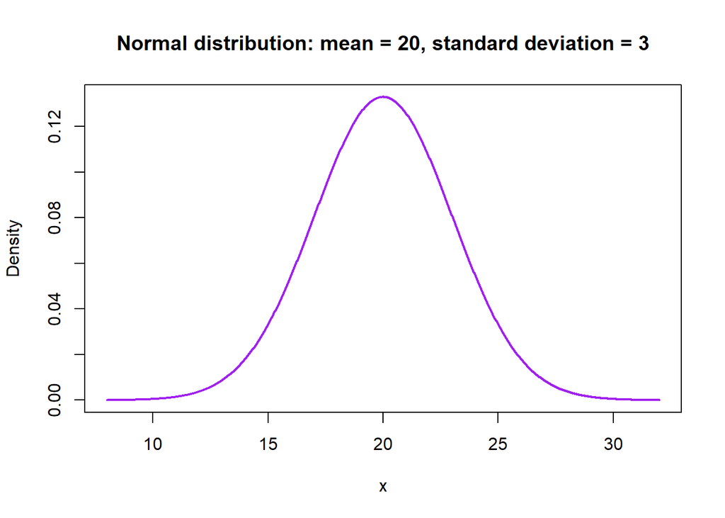

```r
x <- seq(mu - 4 * sigma, mu + 4 * sigma, length.out = 1000)

plot(x, dnorm(x, mean = mu, sd = sigma),
     type = "l", lwd = 2, col = "purple",
     xlab = "x", ylab = "Density",
     main = "Normal distribution: mean = 20, standard deviation = 3")
```

## Exercise 9: Sampling from `ChickWeight`

Using the `ChickWeight` dataset, obtain a statistical summary of `weight`, draw a random sample of 30 records called `my_sample`, store it in a new data frame and check whether the sample’s `weight` distribution is similar to the original one.

```r
data("ChickWeight")

summary(ChickWeight$weight)
```

```
##    Min. 1st Qu.  Median    Mean 3rd Qu.    Max.
##    35.0    63.0   103.0   121.8   163.8   373.0
```

```r
set.seed(969)
sample_rows <- sample(nrow(ChickWeight), size = 30)
my_sample   <- as.data.frame(ChickWeight[sample_rows, ])

summary(my_sample$weight)
```

```
##    Min. 1st Qu.  Median    Mean 3rd Qu.    Max.
##   35.00   60.75   92.50  108.23  140.25  291.00
```

To compare both distributions, we place the summaries side by side and plot them on the same scale.

```r
rbind(population = summary(ChickWeight$weight),
      sample     = summary(my_sample$weight))
```

```
##            Min. 1st Qu. Median     Mean 3rd Qu. Max.
## population   35   63.00  103.0 121.8183  163.75  373
## sample       35   60.75   92.5 108.2333  140.25  291
```

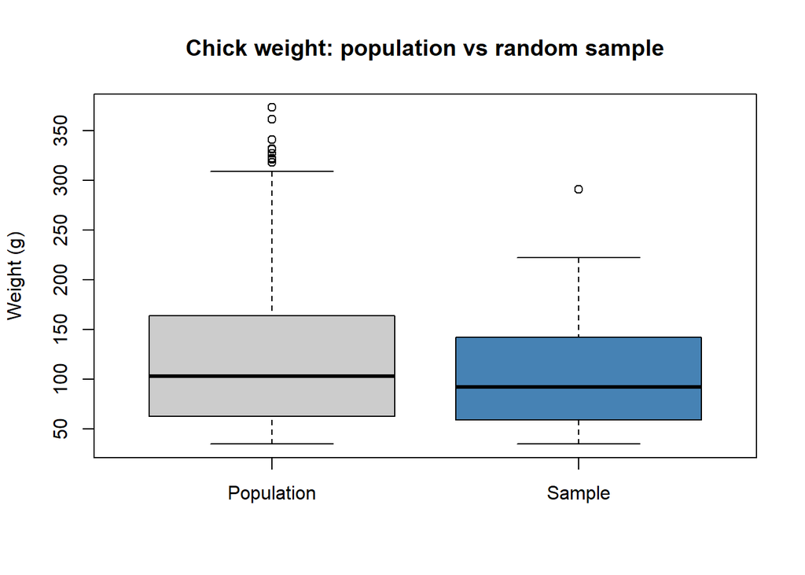

```r
boxplot(list(Population = ChickWeight$weight, Sample = my_sample$weight),
        col  = c("grey80", "steelblue"),
        main = "Chick weight: population vs random sample",
        ylab = "Weight (g)")
```

The sample reproduces the main features of the population (centre, spread and right skew), although with only 30 records the quartiles and extremes vary. A larger sample would match the population more closely.

## Exercise 10: Applied problems

**a)** A drug reduces the effects of pollen allergy; it has been ineffective in only 4% of cases. What type of distribution is this? What is the probability that, if the treatment is applied 100 times, there are **more than 5** ineffective cases?

This is a **binomial** distribution: we count the number of “successes” (ineffective cases) in a fixed number of independent Bernoulli trials (each application is either effective or not), with a constant probability $p = 0.04$.

```r
pbinom(5, size = 100, prob = 0.04, lower.tail = FALSE)
```

```
## [1] 0.2116251
```

**b)** The mean recovery time from a common flu is $7 \pm 2$ days (mean and standard deviation). Assuming a normal distribution, compute the probability that recovery lasts **between 6 and 10 days**.

```r
pnorm(10, mean = 7, sd = 2) - pnorm(6, mean = 7, sd = 2)
```

```
## [1] 0.6246553
```

## Cumulative case study: Old Faithful geyser

We study the distribution of the one-dimensional variable `eruptions` from the `faithful` dataset (built into R’s `datasets` package). It contains the waiting time between eruptions (`waiting`, minutes) and the eruption duration (`eruptions`, minutes) of the Old Faithful geyser in Yellowstone National Park, Wyoming, USA.

**a)** Descriptive statistics of `eruptions`.

```r
data("faithful")

summary(faithful$eruptions)
```

```
##    Min. 1st Qu.  Median    Mean 3rd Qu.    Max.
##   1.600   2.163   4.000   3.488   4.454   5.100
```

```r
c(sd = sd(faithful$eruptions), IQR = IQR(faithful$eruptions))
```

```
##       sd      IQR
## 1.141371 2.291500
```

The mean (3.49) is lower than the median (4.00), which suggests a skewed distribution. The standard deviation (1.14) and the IQR (2.29) are large compared with the mean, so the data are widely spread.

**b)** Stem-and-leaf plot.

```r
stem(faithful$eruptions)
```

```
##
##   The decimal point is 1 digit(s) to the left of the |
##
##   16 | 070355555588
##   18 | 000022233333335577777777888822335777888
##   20 | 00002223378800035778
##   22 | 0002335578023578
##   24 | 00228
##   26 | 23
##   28 | 080
##   30 | 7
##   32 | 2337
##   34 | 250077
##   36 | 0000823577
##   38 | 2333335582225577
##   40 | 0000003357788888002233555577778
##   42 | 03335555778800233333555577778
##   44 | 02222335557780000000023333357778888
##   46 | 0000233357700000023578
##   48 | 00000022335800333
##   50 | 0370
```

Two groups of values are visible: one around 2 minutes and another around 4 to 4.5 minutes.

**c)** Histogram with smaller intervals and the density estimate superimposed.

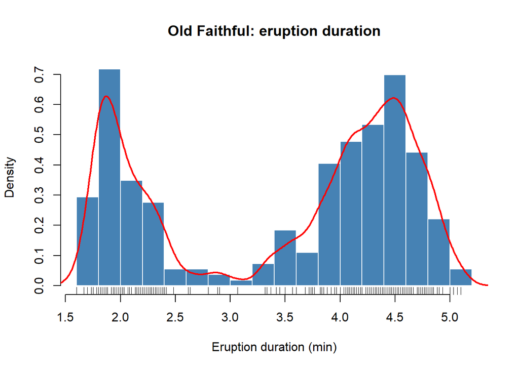

```r
hist(faithful$eruptions,
     breaks = seq(1.6, 5.2, by = 0.2),
     prob   = TRUE,
     col    = "steelblue",
     border = "white",
     main   = "Old Faithful: eruption duration",
     xlab   = "Eruption duration (min)",
     ylab   = "Density")
lines(density(faithful$eruptions, bw = 0.1), col = "red", lwd = 2)
rug(faithful$eruptions)
```

**d)** Empirical cumulative distribution function (ECDF), using `ecdf()` from the `stats` package.

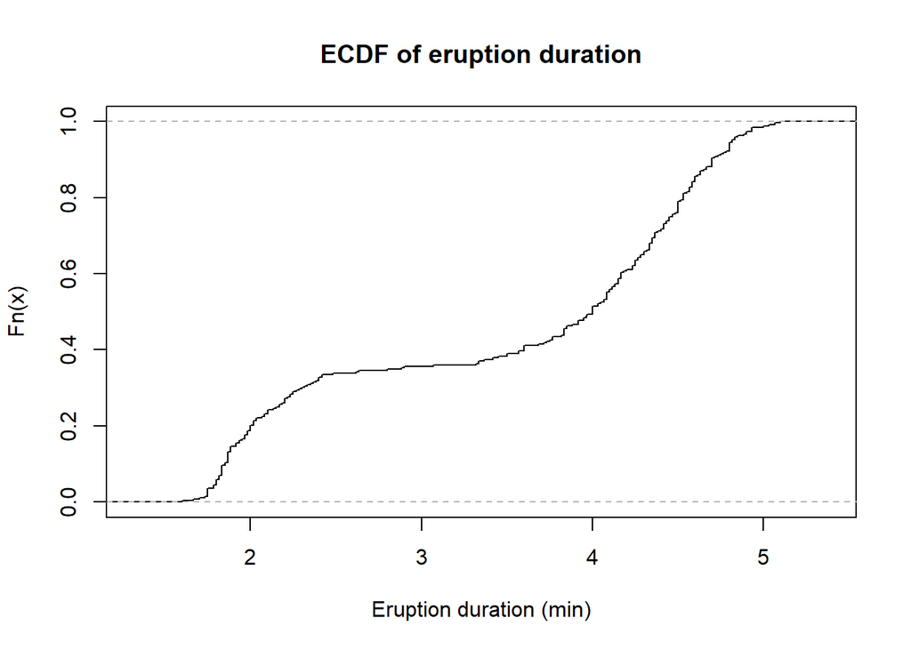

```r
plot(ecdf(faithful$eruptions),
     do.points = FALSE, verticals = TRUE,
     main = "ECDF of eruption duration",
     xlab = "Eruption duration (min)",
     ylab = "Fn(x)")
```

**e)** Does this distribution correspond to any standard distribution?

No. The histogram has **two modes** (bimodal), while the normal distribution has a single one. A Shapiro-Wilk test confirms it:

```r
shapiro.test(faithful$eruptions)
```

```
##
##  Shapiro-Wilk normality test
##
## data:  faithful$eruptions
## W = 0.84592, p-value = 9.036e-16
```

The p-value is far below 0.05, so normality is rejected. The data look like a **mixture of two populations**: short eruptions and long eruptions.

```r
table(duration = ifelse(faithful$eruptions > 3, "long (> 3 min)", "short (<= 3 min)"))
```

```
## duration
##   long (> 3 min) short (<= 3 min)
##              175               97
```

**f)** Select the eruptions lasting **more than 3 minutes**. What can we say about these data?

The filter must use `eruptions` (duration), not `waiting` (time between eruptions).

```r
long_eruptions <- subset(faithful, eruptions > 3)

nrow(long_eruptions)
```

```
## [1] 175
```

```r
summary(long_eruptions$eruptions)
```

```
##    Min. 1st Qu.  Median    Mean 3rd Qu.    Max.
##   3.067   4.033   4.333   4.291   4.583   5.100
```

```r
sd(long_eruptions$eruptions)
```

```
## [1] 0.4108516
```

Mean (4.29) and median (4.33) are almost identical and the second mode has disappeared, so the long eruptions are **symmetric and unimodal**.

**g)** Plot the ECDF of these data and superimpose the cumulative distribution of a normal with the same mean and standard deviation.

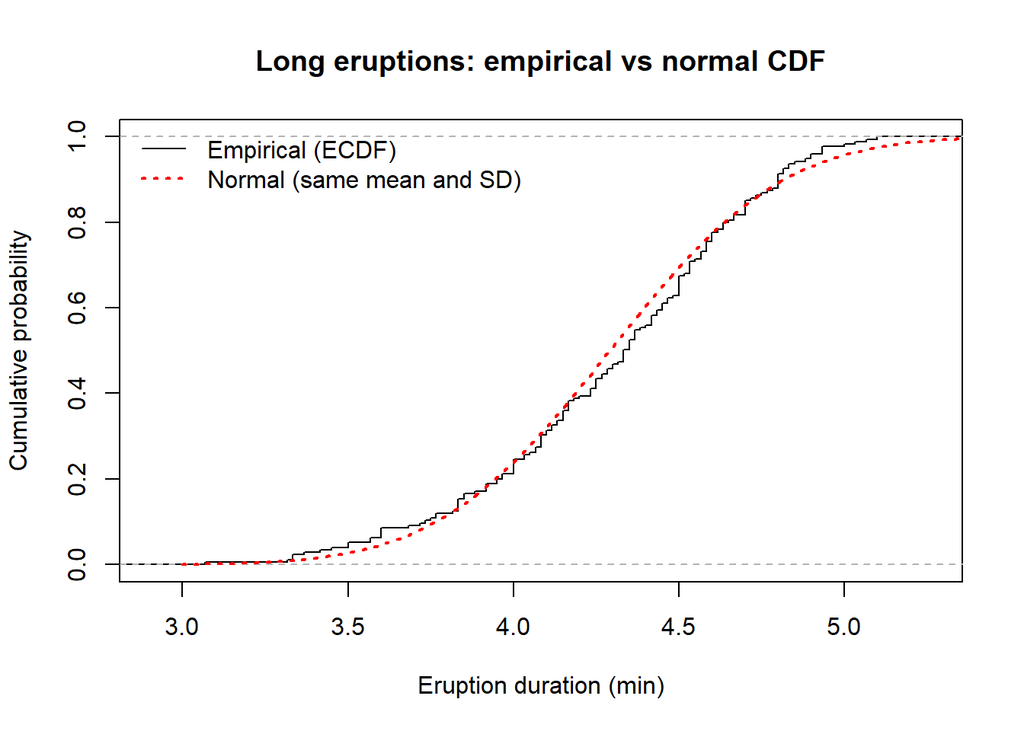

```r
long_mean <- mean(long_eruptions$eruptions)
long_sd   <- sd(long_eruptions$eruptions)

plot(ecdf(long_eruptions$eruptions),
     do.points = FALSE, verticals = TRUE,
     main = "Long eruptions: empirical vs normal CDF",
     xlab = "Eruption duration (min)",
     ylab = "Cumulative probability")

x <- seq(3, 5.4, by = 0.01)
lines(x, pnorm(x, mean = long_mean, sd = long_sd), lty = 3, col = "red", lwd = 2)

legend("topleft",
       legend = c("Empirical (ECDF)", "Normal (same mean and SD)"),
       lty = c(1, 3), col = c("black", "red"), lwd = c(1, 2), bty = "n")
```

**h)** Do these data resemble any distribution?

The two curves are very close. We complement the visual check with formal tests against the normal distribution:

```r
ks.test(long_eruptions$eruptions, "pnorm", mean = long_mean, sd = long_sd)
```

```
##
##  Asymptotic one-sample Kolmogorov-Smirnov test
##
## data:  long_eruptions$eruptions
## D = 0.066133, p-value = 0.4284
## alternative hypothesis: two-sided
```

```r
shapiro.test(long_eruptions$eruptions)
```

```
##
##  Shapiro-Wilk normality test
##
## data:  long_eruptions$eruptions
## W = 0.97934, p-value = 0.01052
```

The Kolmogorov-Smirnov test does not reject the normal model. The Shapiro-Wilk test is stricter and gives a small p-value, but with 175 observations it detects even tiny departures from normality. Overall, the long eruptions are **well approximated by a normal distribution** with mean 4.29 and standard deviation 0.41. Separating the two groups explains the bimodal shape of the full dataset: it is a mixture of a short-eruption group and an approximately normal long-eruption group.

*Note:* the KS p-value is only approximate here: the data contain tied values (durations are recorded with limited precision) and the normal parameters were estimated from the same sample. Treat it as supporting evidence, together with the ECDF plot, rather than as an exact test.